# HW 3: From correlation to linear mixed-effect models

## 1. Vowel reduction in Russian

Pavel Duryagin ran an experiment on perception of vowel reduction in Russian language. The dataset `shva` includes the following variables:  
*time1* - reaction time 1  
*duration* - duration of the vowel in the stimuly (in milliseconds, ms)  
*time2* - reaction time 2  
*f1*, *f2*, *f3* - the 1st, 2nd and 3rd formant of the vowel measured in Hz (for a short introduction into formants, see [here](https://home.cc.umanitoba.ca/~krussll/phonetics/acoustic/formants.html))  
*vowel* - vowel classified according the 3-fold classification (*A* - *a* under stress, *a* - *a/o* as in the first syllable before the stressed one, *y* (stands for shva) - *a/o* as in the second etc. syllable before the stressed one or after the stressed syllable, cf. *g*[*y*]*g*[*a*]*t*[*A*]*l*[*y*] *gogotala* `guffawed’).  
In this part, we will ask you to analyse correlation between f1, f2, and duration. The dataset is available https://raw.githubusercontent.com/agricolamz/2018-MAG_R_course/master/data/duryagin_ReductionRussian.txt.

### 1.0 Read the data from file to the variable `shva`.

### 1.1 Scatterplot *f1* and *f2*

using ggplot(). Design it to look like the following:

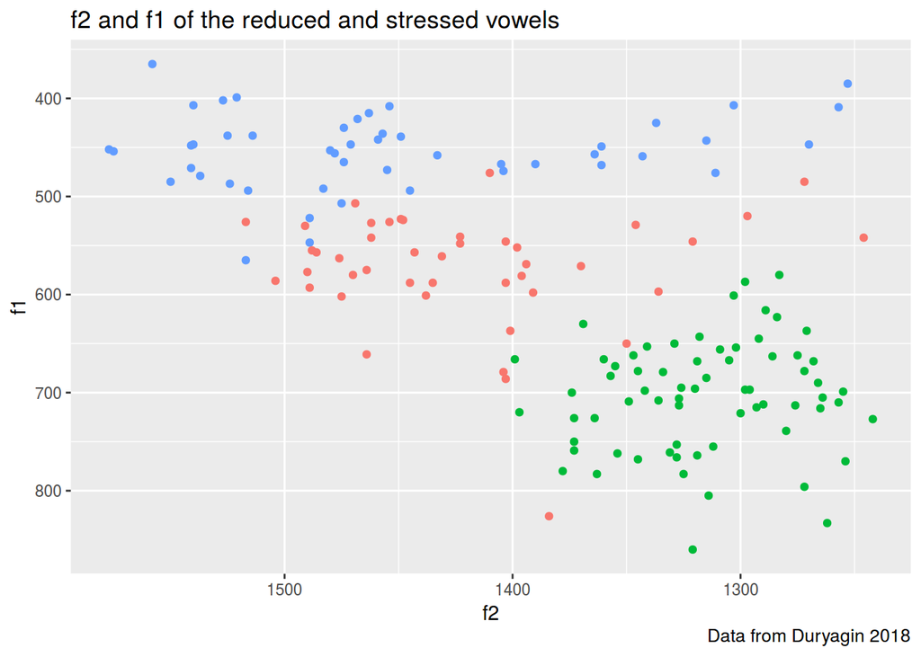

### 1.2 Plot the boxplots of *f1* and *f2* for each vowel using `ggplot()`.

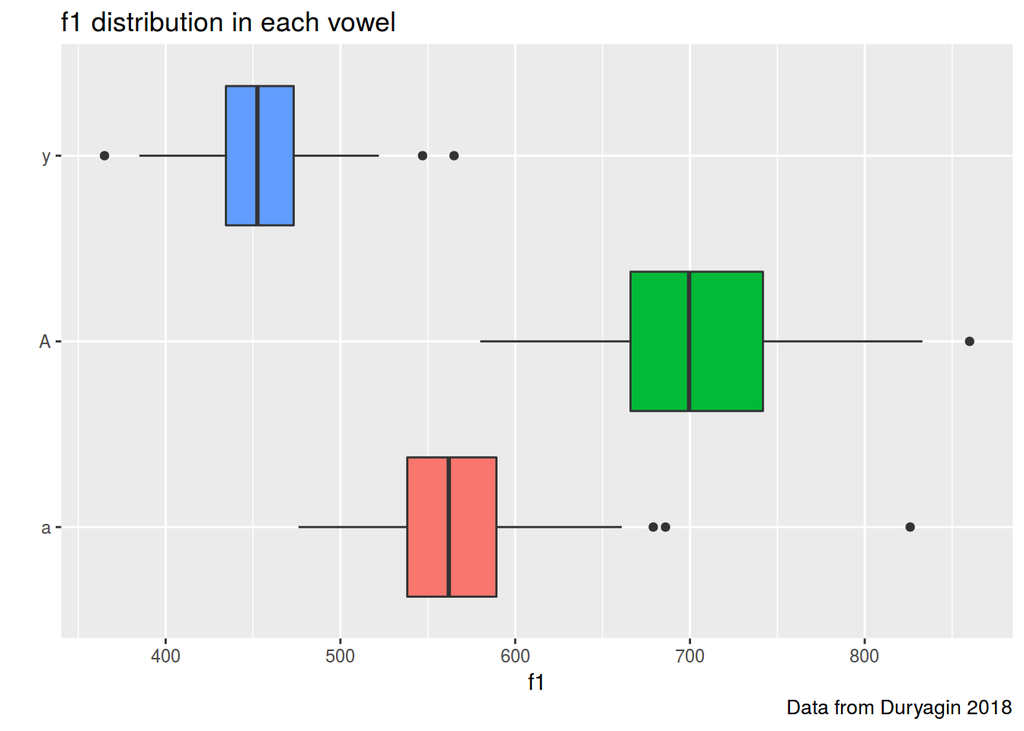

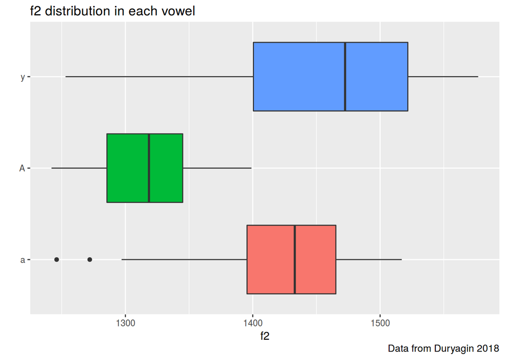

### 1.3 Which *f1* can be considered outliers in *a* vowel?

We assume outliers to be those observations that lie outside 1.5 * IQR, where IQR, the ‘Inter Quartile Range’, is the difference between the 1st and the 3rd quartile (= 25% and 75% percentile).

### 1.4 Calculate Pearson’s correlation of f1 and f2 (all data)

### 1.5 Calculate Pearson’s correlation of f1 and f2 for each vowel

### 1.6 Use the linear regression model to predict f2 by f1.

#### 1.6.1 Provide the result regression formula

#### 1.6.2 Provide the adjusted R$^2$

#### 1.6.3 Add the regression line in scatterplot 1.1

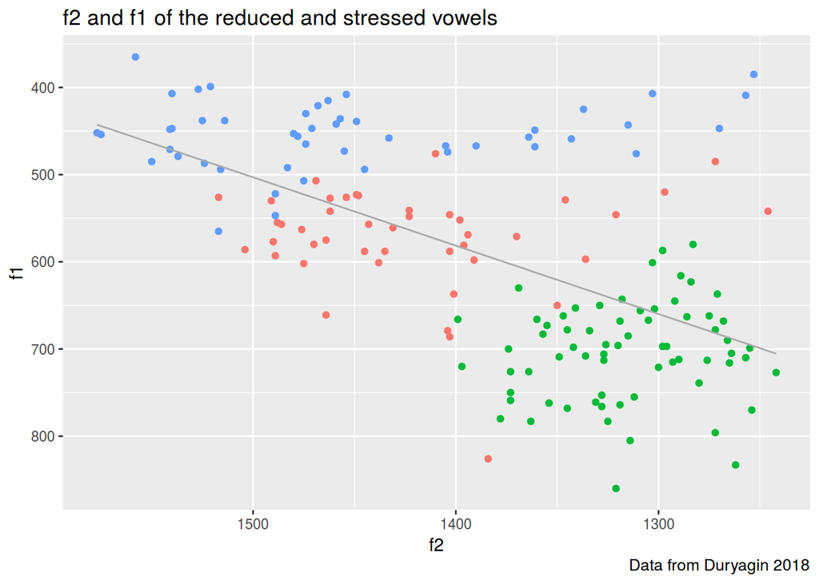

### 1.7 Use the mixed-efects model to predict f2 by f1 using vowel intercept as a random effect

#### 1.7.1 Provide the fixed effects formula

#### 1.7.2 Provide the variance for intercept argument for vowel random effects

#### 1.7.3 Add the regression line in scatterplot 1.1

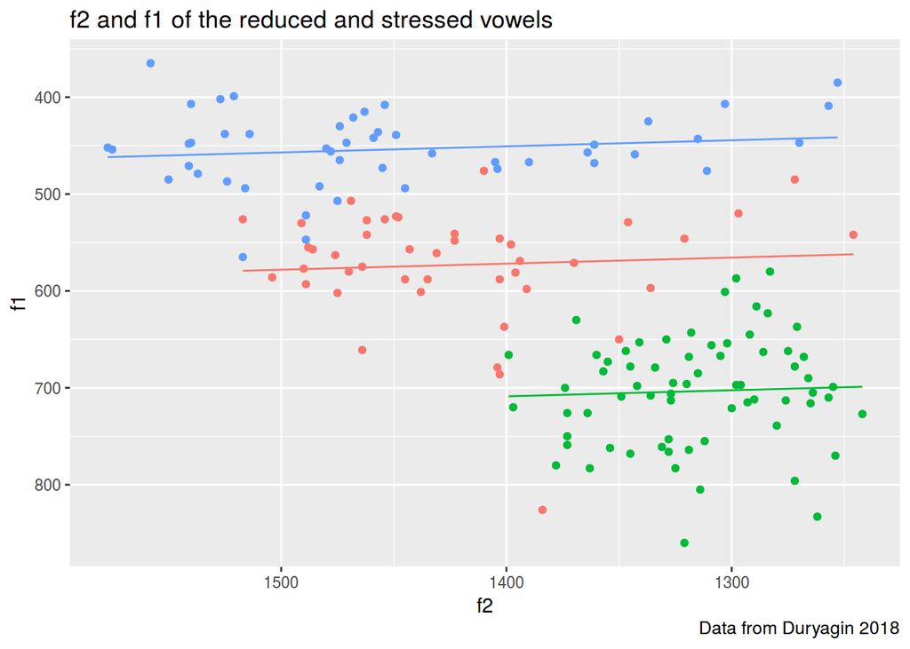

## 2. English Lexicon Project data

880 nouns, adjectives and verbs from the English Lexicon Project data (Balota et al. 2007).

- Format – A data frame with 880 observations on the following 5 variables.
- Word – a factor with lexical stimuli.
- Length – a numeric vector with word lengths.
- SUBTLWF – a numeric vector with frequencies in film subtitles.
- POS – a factor with levels JJ (adjective) NN (noun) VB (verb)
- Mean_RT – a numeric vector with mean reaction times in a lexical decision task Source (http://elexicon.wustl.edu/WordStart.asp)

Data from Natalya Levshina’s `RLing` package available (here)[https://raw.githubusercontent.com/agricolamz/2018-MAG_R_course/master/data/ELP.csv]

### 2.0 Read the data from file to the variable `elp`.

### 2.1 Which two variables have the highest Pearson’s correlaton value.

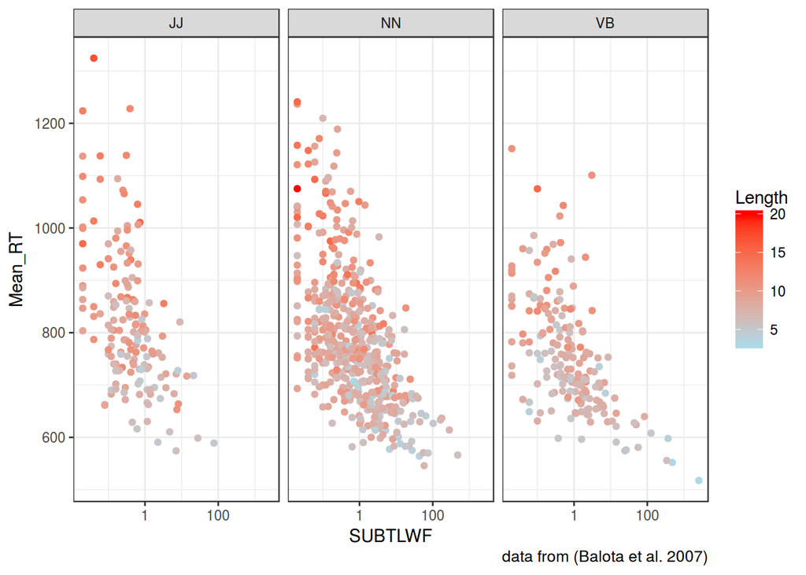

I’ve used `scale_color_continuous(low = "lightblue", high = "red")`

### 2.3 Use the linear regression model to predict Mean_RT by log(SUBTLWF) and POS.

#### 2.3.1 Provide the result regression formula

#### 2.3.2 Provide the adjusted R$^2$

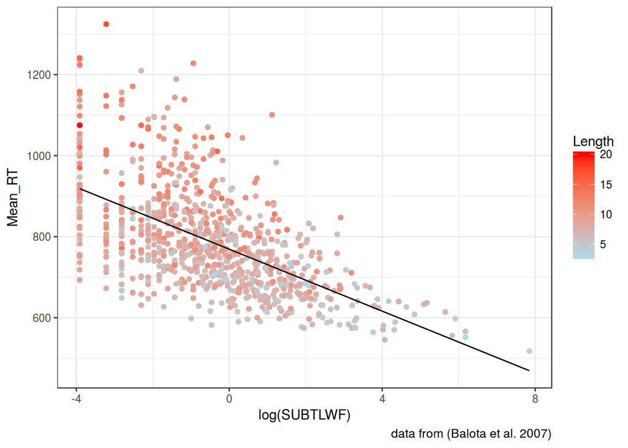

#### 2.4.1 Provide the fixed effects formula

#### 2.4.2 Provide the variance for intercept argument for POS random effects

#### 2.4.3 Add the regression line to scatterplot

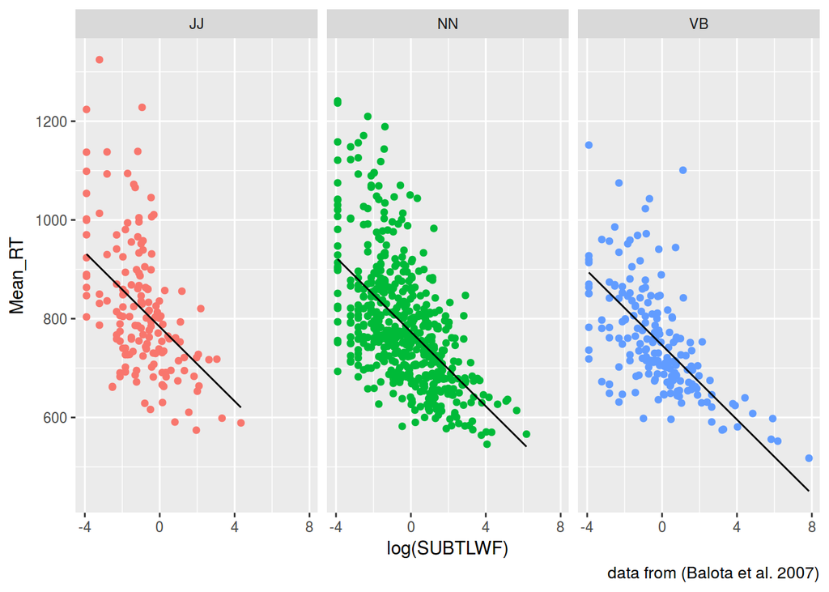

## 3. Dutch causative constructions

A data set with examples of two Dutch periphrastic causatives from newspaper corpora.

A data frame with 100 observations on the following 7 variables.

- Cx – a factor with levels doen_V and laten_V
- CrSem – a factor that contains the semantic class of the Causer with levels Anim (animate) and Inanim (inanimate).
- CeSem – a factor that describes the semantic class of the Causee with levels Anim (animate) and Inanim (inanimate).
- CdEv – a factor that describes the semantic domain of the caused event expressed by the Effected Predicate. The levels are Ment (mental), Phys (physical) and Soc (social).
- Neg – a factor with levels No (absence of negation) and Yes (presence of negation).
- Coref – a factor with levels No (no coreferentiality) and Yes (coreferentiality).
- Poss – a factor with levels No (no overt expression of possession) Yes (overt expression of possession)

Data from Natalya Levshina’s `RLing` package available (here)[https://raw.githubusercontent.com/agricolamz/2018-MAG_R_course/master/data/dutch_causatives.csv]

### 3.5 Provide here a short text (300 words) describing results of your analysis.